# Customer Churn Analysis — Clustering Analysis

**Project:** Customer Churn Analysis for Advanced Telecommunications Solutions (ATS)

**Notebook role:** Data Analyst — Clustering Analysis

**Author:** Ruyu (Grace) Liu

### Purpose of this notebook

Per the official role brief, this notebook segments customers using **K-Means clustering, based on similarities in `tenure` and `MonthlyCharges`**. The workflow follows the Stage 2 Clustering Analysis deliverables:

1. Review and select a clustering algorithm
2. Determine the optimal number of clusters (Elbow Method)
3. Train the K-Means model
4. Interpret the resulting clusters
5. Visualise and label the clusters
6. Export cluster assignments for the Business Analyst and (optionally) the Predictive Modeling DA

### Data used in this notebook

The dataset used here was prepared and handed off by the **Data Engineer**, as two files:

- `clustering_features_scaled.csv` — scaled `tenure` and `MonthlyCharges` (the only features K-Means is trained on), plus a `row_id` key
- `full_encoded_cleaned.csv` — the full cleaned and encoded dataset (all features, unscaled), also keyed by `row_id`

These are treated here as an **external input**, not something already familiar from earlier work in this notebook. Before using either file for modelling, this notebook independently checks that the data is complete, that `tenure` and `MonthlyCharges` behave as expected, and explores the relationship between these two features and `Churn` — all as a standalone starting point for the clustering analysis, rather than assuming any prior exploration.

**A note on scope:** Not everything here will belong in the final report — sections are written to be thorough for review purposes, and can be trimmed down by the Business Analyst when compiling the final deliverable.

> 🗂️ **Jira Task — Sprint 2 (Epic: Clustering Analysis):** Load and validate the data received from the Data Engineer

## 1. Import Libraries

```python
# Core data handling
import pandas as pd
import numpy as np

# Visualisation
import matplotlib.pyplot as plt
import seaborn as sns

# Clustering
from sklearn.cluster import KMeans
from sklearn.metrics import silhouette_score

# File handling and model saving
import os
import joblib

sns.set_style("whitegrid")
plt.rcParams["figure.figsize"] = (7, 4)
pd.set_option("display.max_columns", None)

# Output folders (created next to this notebook, inside Clustering_Analysis/)
for folder in ["Optimal_Clusters", "Model", "Cluster_Visualisation"]:
    os.makedirs(folder, exist_ok=True)

print("Libraries loaded.")
```

```
Libraries loaded.
```

## 2. Load the Data Received from the Data Engineer

Two files are loaded here, for two different purposes:

- `clustering_features_scaled.csv` — this is the **only** data K-Means is trained on (scaled `tenure` and `MonthlyCharges`)
- `full_encoded_cleaned.csv` — loaded now, but not used until Section 7 (Interpretation), where it's joined back in via `row_id` to profile the resulting clusters using the full feature set

Since these files are an external input to this notebook (prepared upstream by the Data Engineer), they're treated with the same care as any dataset received from outside — loaded, previewed, and validated below before being relied on for modelling.

```python
# Clustering-ready features (scaled tenure + MonthlyCharges, with row_id)
cluster_df = pd.read_csv("../Data_Preparation/processed/clustering_features_scaled.csv")
print(f"cluster_df shape: {cluster_df.shape}")
cluster_df.head()
```

```
cluster_df shape: (7043, 3)
```

|  | row_id | tenure_scaled | MonthlyCharges_scaled |
| --- | --- | --- | --- |
| 0 | 0 | -1.277445 | -1.321350 |
| 1 | 1 | 0.351370 | -1.321350 |
| 2 | 2 | 0.799294 | -1.520755 |
| 3 | 3 | -1.277445 | 0.373593 |
| 4 | 4 | 1.410099 | -0.457261 |

```python
# Full encoded dataset — loaded now, used later for cluster interpretation (Section 7)
full_df = pd.read_csv("../Data_Preparation/processed/full_encoded_cleaned.csv")
print(f"full_df shape: {full_df.shape}")
full_df.head()
```

```
full_df shape: (7043, 13)
```

|  | row_id | gender | SeniorCitizen | Dependents | tenure | PhoneService | MultipleLines | InternetService | MonthlyCharges | Churn | Contract_Month-to-month | Contract_One year | Contract_Two year |
| --- | --- | --- | --- | --- | --- | --- | --- | --- | --- | --- | --- | --- | --- |
| 0 | 0 | 0 | 0 | 0 | 1 | 0 | 0 | 0 | 25 | 1 | 1 | 0 | 0 |
| 1 | 1 | 1 | 0 | 0 | 41 | 1 | 0 | 0 | 25 | 0 | 0 | 1 | 0 |
| 2 | 2 | 0 | 0 | 1 | 52 | 1 | 0 | 0 | 19 | 0 | 1 | 0 | 0 |
| 3 | 3 | 0 | 0 | 0 | 1 | 1 | 0 | 0 | 76 | 1 | 0 | 1 | 0 |
| 4 | 4 | 1 | 0 | 0 | 67 | 1 | 0 | 1 | 51 | 0 | 1 | 0 | 0 |

**Validating the received data:** Both files should have the same number of rows and share the `row_id` column, since they're two views of the same underlying cleaned dataset. Rather than assume this is the case, it's confirmed explicitly below — this is standard due diligence whenever a dataset arrives from another part of the pipeline.

The merge itself is also validated with `validate="one_to_one"` — this makes pandas raise an error immediately if `row_id` turns out not to be a true 1:1 key between the two files (e.g. due to an unexpected duplicate), rather than silently producing duplicated or misaligned rows further down the notebook.

```python
assert cluster_df.shape[0] == full_df.shape[0], "Row count mismatch between the two files!"
assert set(cluster_df["row_id"]) == set(full_df["row_id"]), "row_id values don't match between the two files!"

# validate="one_to_one" raises an error if row_id is not a safe 1:1 join key
_ = cluster_df.merge(full_df, on="row_id", how="left", validate="one_to_one")
print("Row counts, row_id values, and one-to-one join integrity all confirmed — safe to proceed.")
```

```
Row counts, row_id values, and one-to-one join integrity all confirmed — safe to proceed.
```

```python
# Quick structural check: confirm there are no missing values in either file,
# and that dtypes look as expected before any modelling begins
print("Missing values in cluster_df:")
print(cluster_df.isnull().sum())
print("\nMissing values in full_df:")
print(full_df.isnull().sum().sum(), "total missing cells across all columns")
print("\ncluster_df dtypes:")
print(cluster_df.dtypes)
```

```
Missing values in cluster_df:
row_id                   0
tenure_scaled            0
MonthlyCharges_scaled    0
dtype: int64

Missing values in full_df:
0 total missing cells across all columns

cluster_df dtypes:
row_id                     int64
tenure_scaled            float64
MonthlyCharges_scaled    float64
dtype: object
```

**Finding:** No missing values in either file, and both `tenure_scaled` and `MonthlyCharges_scaled` are numeric (`float64`) as expected for K-Means input. The data is fit for purpose.

> 🗂️ **Jira Task — Sprint 2 (Epic: Clustering Analysis):** Independently explore tenure, MonthlyCharges, and their relationship with Churn

## 3. Exploring `tenure` and `MonthlyCharges` Before Modelling

Before training a clustering model, it's worth understanding these two features on their own terms — where the values sit on their original scale, and how they relate to `Churn` — rather than treating them as an opaque pair of numbers to feed into K-Means. The analysis below is done independently here, using the unscaled values available in `full_df` for interpretability.

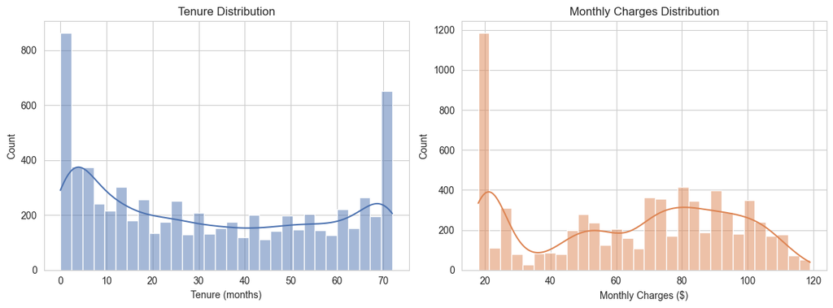

```python
# Distribution of tenure and MonthlyCharges in their original (unscaled) units
fig, axes = plt.subplots(1, 2, figsize=(12, 4.5))

sns.histplot(full_df["tenure"], bins=30, kde=True, ax=axes[0], color="#4C72B0")
axes[0].set_title("Tenure Distribution")
axes[0].set_xlabel("Tenure (months)")

sns.histplot(full_df["MonthlyCharges"], bins=30, kde=True, ax=axes[1], color="#DD8452")
axes[1].set_title("Monthly Charges Distribution")
axes[1].set_xlabel("Monthly Charges ($)")

plt.tight_layout()
plt.show()
```

**Finding:**

`tenure` shows a somewhat bimodal shape — a sizeable group of relatively new customers (low tenure) alongside another group of long-standing customers approaching the maximum observed tenure. This hints that natural customer groupings may exist in the data, which is encouraging for the clustering work that follows.

`MonthlyCharges` is more spread out, with a rise at the lower end (likely customers on basic plans) and a broader spread at higher charges.

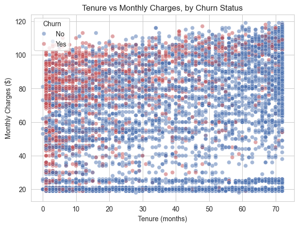

```python
# Relationship between tenure, MonthlyCharges, and Churn
fig, ax = plt.subplots(figsize=(7, 5))
sns.scatterplot(
    data=full_df, x="tenure", y="MonthlyCharges", hue="Churn",
    alpha=0.5, palette={1: "#C44E52", 0: "#4C72B0"}, ax=ax
)
ax.set_title("Tenure vs Monthly Charges, by Churn Status")
ax.set_xlabel("Tenure (months)")
ax.set_ylabel("Monthly Charges ($)")
handles, _ = ax.get_legend_handles_labels()
ax.legend(handles, ["No", "Yes"], title="Churn")
plt.show()
```

**Finding:** Churned customers (red, `Churn=1`) are visibly concentrated in the **low-tenure, higher-charge** region of the plot, while long-tenure customers churn far less often regardless of charge level.

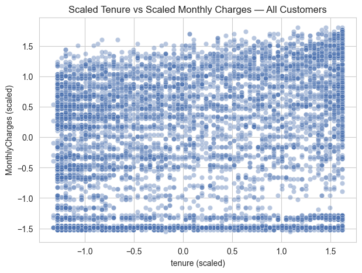

```python
fig, ax = plt.subplots(figsize=(7, 5))
sns.scatterplot(data=cluster_df, x="tenure_scaled", y="MonthlyCharges_scaled", alpha=0.4, ax=ax, color="#4C72B0")
ax.set_title("Scaled Tenure vs Scaled Monthly Charges — All Customers")
ax.set_xlabel("tenure (scaled)")
ax.set_ylabel("MonthlyCharges (scaled)")
plt.show()
```

**Observation:** This is the same relationship, but shown using the scaled features that will actually be fed into K-Means — confirming the shape of the data going into the model. The scaled data doesn't show obviously separated, distinct blobs by eye — this is fairly typical for real-world customer data (as opposed to synthetic textbook examples), and is exactly why a systematic method (rather than eyeballing the scatterplot) is needed to determine how many clusters actually exist. That's covered next.

> 🗂️ **Jira Task — Sprint 2 (Epic: Clustering Analysis):** Determine optimal number of clusters (Elbow Method + Silhouette Score)

## 4. Determine the Optimal Number of Clusters

Two complementary methods are used here, per the Stage 2 deliverable ("Identified the optimal number of clusters using the elbow method"):

1. **Elbow Method** — plots inertia (within-cluster sum of squared distances) against *k*. As *k* increases, inertia always decreases, but the rate of improvement drops off sharply after the "true" number of clusters — visually, this looks like an elbow bend in the curve.
2. **Silhouette Score** — measures how well-separated clusters are (ranges from -1 to 1; higher is better). Used here as a cross-check on the Elbow Method's suggestion, since the elbow "bend" can sometimes be subjective to read by eye.

```python
X = cluster_df[["tenure_scaled", "MonthlyCharges_scaled"]].values

k_range = range(2, 11)
inertias = []
silhouette_scores = []

for k in k_range:
    km = KMeans(n_clusters=k, init="k-means++", n_init=10, random_state=42)
    labels = km.fit_predict(X)
    inertias.append(km.inertia_)
    silhouette_scores.append(silhouette_score(X, labels))

results_df = pd.DataFrame({"k": list(k_range), "inertia": inertias, "silhouette_score": silhouette_scores})
results_df
```

|  | k | inertia | silhouette_score |
| --- | --- | --- | --- |
| 0 | 2 | 7841.448888 | 0.410879 |
| 1 | 3 | 4622.446769 | 0.446396 |
| 2 | 4 | 2846.346394 | 0.476050 |
| 3 | 5 | 2339.082354 | 0.429732 |
| 4 | 6 | 1929.162321 | 0.415487 |
| 5 | 7 | 1556.144222 | 0.433954 |
| 6 | 8 | 1344.877411 | 0.434109 |
| 7 | 9 | 1149.204621 | 0.440168 |
| 8 | 10 | 1008.092499 | 0.430608 |

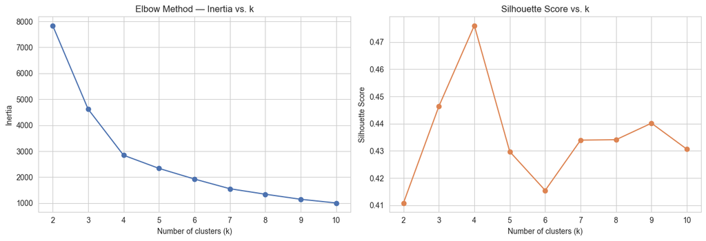

```python
fig, axes = plt.subplots(1, 2, figsize=(13, 4.5))

# Elbow plot
axes[0].plot(results_df["k"], results_df["inertia"], marker="o", color="#4C72B0")
axes[0].set_title("Elbow Method — Inertia vs. k")
axes[0].set_xlabel("Number of clusters (k)")
axes[0].set_ylabel("Inertia")
axes[0].set_xticks(list(k_range))

# Silhouette plot
axes[1].plot(results_df["k"], results_df["silhouette_score"], marker="o", color="#DD8452")
axes[1].set_title("Silhouette Score vs. k")
axes[1].set_xlabel("Number of clusters (k)")
axes[1].set_ylabel("Silhouette Score")
axes[1].set_xticks(list(k_range))

plt.tight_layout()
plt.savefig("Optimal_Clusters/elbow_silhouette.png", dpi=300, bbox_inches="tight")
plt.show()

# Save the numbers behind the plots as supporting evidence for the choice of k
results_df.to_csv("Optimal_Clusters/k_selection_results.csv", index=False)
```

**Finding:**

- The Elbow plot shows a steep drop in inertia from k=2 through k=4, with the rate of improvement flattening out noticeably from around **k=4** onward — this is the "elbow."
- The Silhouette Score **peaks at k=4** (≈0.476) — higher than k=2 (≈0.411), k=3 (≈0.446), and k=5 (≈0.430). This is a stronger result than typically expected: both methods agree cleanly on the same value, rather than requiring a judgment call between conflicting signals.

**Decision:** **k=4** is selected. It sits at the elbow bend, and also happens to be the single best-separated clustering option per the Silhouette Score — both methods point to the same answer. It also gives enough granularity to distinguish more than just "high risk vs. low risk" (a 2-cluster split), which matters for how actionable the retention strategy recommendations in the final report can be.

> 🗂️ **Jira Task — Sprint 2 (Epic: Clustering Analysis):** Train K-Means model on the dataset

## 5. Train the K-Means Model

Training the final model with **k=4**, using the same scaled features.

```python
k_final = 4

kmeans_final = KMeans(n_clusters=k_final, init="k-means++", n_init=10, random_state=42)
cluster_df["cluster"] = kmeans_final.fit_predict(X)

print(f"Model trained with k={k_final}")
print("\nCluster sizes:")
print(cluster_df["cluster"].value_counts().sort_index())
```

```
Model trained with k=4

Cluster sizes:
cluster
0    2202
1    1733
2    1948
3    1160
Name: count, dtype: int64
```

**Finding:** All four clusters contain a substantial number of customers (no cluster is negligibly small), suggesting the split is meaningful rather than an artifact of one or two outlier points forming their own group.

### Save the Trained Model

The trained K-Means model is saved to disk so it can be reloaded later without retraining. The check below reloads it and confirms it reproduces exactly the same cluster assignments.

To use it on new data, the two input features must first be scaled in the same way as the training data (scaled `tenure` and `MonthlyCharges`), then passed to `model.predict()`.

```python
joblib.dump(kmeans_final, "Model/kmeans_model.joblib")

# Verify: the reloaded model must reproduce the same cluster assignments
loaded_model = joblib.load("Model/kmeans_model.joblib")
assert (loaded_model.predict(X) == cluster_df["cluster"].values).all(), "Reloaded model gives different assignments!"

print("Model saved to Model/kmeans_model.joblib and verified.")
print(f"Number of clusters: {loaded_model.n_clusters}")
print("Cluster centres (scaled feature space):")
print(loaded_model.cluster_centers_.round(3))
```

```
Model saved to Model/kmeans_model.joblib and verified.
Number of clusters: 4
Cluster centres (scaled feature space):
[[-0.715  0.547]
 [-0.892 -1.073]
 [ 1.075  0.941]
 [ 0.885 -1.017]]
```

> 🗂️ **Jira Task — Sprint 2 (Epic: Clustering Analysis):** Visualise clusters

## 6. Visualise Clusters

The clusters are plotted below in two ways:

1. **Scaled feature space** — what K-Means actually "sees" when assigning clusters, with the cluster centroids marked
2. **Original (unscaled) feature space** — `tenure` in months and `MonthlyCharges` in dollars.

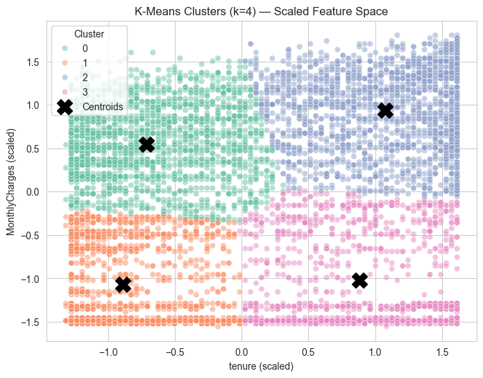

```python
fig, ax = plt.subplots(figsize=(8, 6))

palette = sns.color_palette("Set2", k_final)
sns.scatterplot(
    data=cluster_df, x="tenure_scaled", y="MonthlyCharges_scaled",
    hue="cluster", palette=palette, alpha=0.5, ax=ax
)

# Plot centroids
centroids = kmeans_final.cluster_centers_
ax.scatter(centroids[:, 0], centroids[:, 1], marker="X", s=250, c="black", label="Centroids", zorder=5)

ax.set_title(f"K-Means Clusters (k={k_final}) — Scaled Feature Space")
ax.set_xlabel("tenure (scaled)")
ax.set_ylabel("MonthlyCharges (scaled)")
ax.legend(title="Cluster")
plt.savefig("Cluster_Visualisation/clusters_scaled.png", dpi=300, bbox_inches="tight")
plt.show()
```

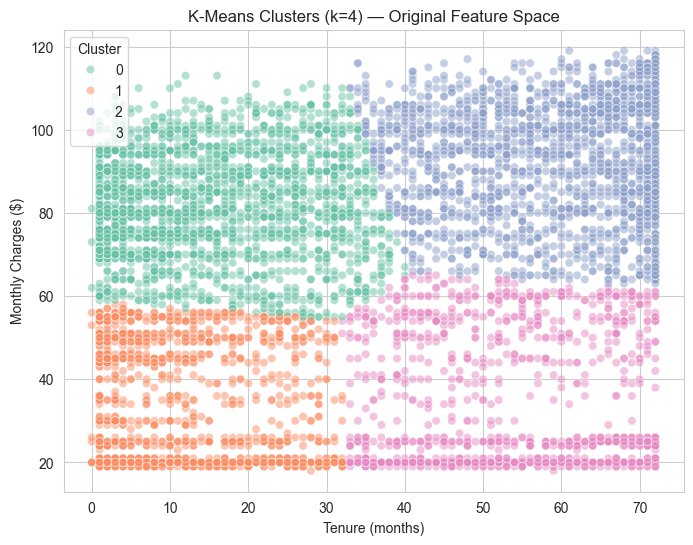

```python
# Bring in the original (unscaled) tenure/MonthlyCharges values for a more interpretable plot.
# full_df has the original values under the same row_id, joined in here.
cluster_df_readable = cluster_df.merge(
    full_df[["row_id", "tenure", "MonthlyCharges"]], on="row_id", how="left"
)

fig, ax = plt.subplots(figsize=(8, 6))
sns.scatterplot(
    data=cluster_df_readable, x="tenure", y="MonthlyCharges",
    hue="cluster", palette=palette, alpha=0.5, ax=ax
)
ax.set_title(f"K-Means Clusters (k={k_final}) — Original Feature Space")
ax.set_xlabel("Tenure (months)")
ax.set_ylabel("Monthly Charges ($)")
ax.legend(title="Cluster")
plt.savefig("Cluster_Visualisation/clusters_original.png", dpi=300, bbox_inches="tight")
plt.show()
```

**Finding:** In the original feature space, the four clusters roughly correspond to combinations of low/high tenure and low/high monthly charges — the exact business meaning of each is examined properly in the next section, where categorical features and Churn are joined back in.

> 🗂️ **Jira Task — Sprint 2 (Epic: Clustering Analysis):** Interpret the resulting clusters

## 7. Interpret & Label Clusters

This is where `full_encoded_cleaned.csv` gets joined in via `row_id`, so each cluster can be profiled using the fields that weren't part of the clustering itself — `Contract`, `InternetService`, `Dependents`, and critically, `Churn`.

Since categorical features in this file are already encoded as 0/1, the file alone doesn't reveal which raw category each number corresponds to (e.g. whether `0` means "Female" or "Male"). Rather than assume a direction, this is checked directly against the original source dataset (`Dataset_ATS_v2.csv`) below.

```python
# Cross-check the encoding direction against the original raw dataset.
# Note: this assumes row_id corresponds to the raw file's row order (0-indexed) — reasonable
# here since the raw dataset has no unique ID column, but worth confirming with the Data
# Engineer if the encoded file is ever regenerated with a different row order.
raw_df = pd.read_csv("../Data_Preparation/Dataset_ATS_v2.csv")
raw_df_indexed = raw_df.reset_index().rename(columns={"index": "row_id"})

encoding_check = full_df.merge(
    raw_df_indexed[["row_id", "gender", "Dependents", "InternetService", "Churn"]],
    on="row_id", suffixes=("_encoded", "_raw")
)

for col in ["gender", "Dependents", "InternetService", "Churn"]:
    mapping = encoding_check[[f"{col}_encoded", f"{col}_raw"]].drop_duplicates().sort_values(f"{col}_encoded")
    print(f"{col}:")
    print(mapping.to_string(index=False))
    print()
```

```
gender:
 gender_encoded gender_raw
              0     Female
              1       Male

Dependents:
 Dependents_encoded Dependents_raw
                  0             No
                  1            Yes

InternetService:
 InternetService_encoded InternetService_raw
                       0                 DSL
                       1         Fiber optic

Churn:
 Churn_encoded Churn_raw
             0        No
             1       Yes
```

**Confirmed encoding:**

`gender` (Female=0, Male=1),

`Dependents` (No=0, Yes=1),

`InternetService` (DSL=0, Fiber optic=1),

`Churn` (No=0, Yes=1) — and by the same pattern,

`PhoneService`/`MultipleLines` also follow No=0/Yes=1.

`Contract` has been one-hot encoded into three separate 0/1 columns, one per contract type.

```python
# Join the full feature set onto the clustered data via row_id
# validate="one_to_one" ensures this join can't silently duplicate or misalign rows
profile_df = cluster_df.merge(full_df, on="row_id", how="left", validate="one_to_one")
print(f"profile_df shape: {profile_df.shape}")
profile_df.head()
```

```
profile_df shape: (7043, 16)
```

|  | row_id | tenure_scaled | MonthlyCharges_scaled | cluster | gender | SeniorCitizen | Dependents | tenure | PhoneService | MultipleLines | InternetService | MonthlyCharges | Churn | Contract_Month-to-month | Contract_One year | Contract_Two year |
| --- | --- | --- | --- | --- | --- | --- | --- | --- | --- | --- | --- | --- | --- | --- | --- | --- |
| 0 | 0 | -1.277445 | -1.321350 | 1 | 0 | 0 | 0 | 1 | 0 | 0 | 0 | 25 | 1 | 1 | 0 | 0 |
| 1 | 1 | 0.351370 | -1.321350 | 3 | 1 | 0 | 0 | 41 | 1 | 0 | 0 | 25 | 0 | 0 | 1 | 0 |
| 2 | 2 | 0.799294 | -1.520755 | 3 | 0 | 0 | 1 | 52 | 1 | 0 | 0 | 19 | 0 | 1 | 0 | 0 |
| 3 | 3 | -1.277445 | 0.373593 | 0 | 0 | 0 | 0 | 1 | 1 | 0 | 0 | 76 | 1 | 0 | 1 | 0 |
| 4 | 4 | 1.410099 | -0.457261 | 3 | 1 | 0 | 0 | 67 | 1 | 0 | 1 | 51 | 0 | 1 | 0 | 0 |

```python
# Numeric profile per cluster: average tenure, MonthlyCharges, and churn rate
cluster_profile = profile_df.groupby("cluster").agg(
    n_customers=("row_id", "count"),
    avg_tenure=("tenure", "mean"),
    avg_monthly_charges=("MonthlyCharges", "mean"),
    churn_rate=("Churn", "mean"),          # mean of a 0/1 column = proportion of Yes
    pct_fiber_optic=("InternetService", "mean"),
    pct_month_to_month=("Contract_Month-to-month", "mean"),
    pct_dependents=("Dependents", "mean"),
).round(3)

cluster_profile
```

| cluster | n_customers | avg_tenure | avg_monthly_charges | churn_rate | pct_fiber_optic | pct_month_to_month | pct_dependents |
| --- | --- | --- | --- | --- | --- | --- | --- |
| 0 | 2202 | 14.811 | 81.231 | 0.492 | 0.430 | 0.561 | 0.196 |
| 1 | 1733 | 10.478 | 32.486 | 0.245 | 0.441 | 0.540 | 0.304 |
| 2 | 1948 | 58.759 | 93.076 | 0.157 | 0.449 | 0.553 | 0.332 |
| 3 | 1160 | 54.100 | 34.151 | 0.048 | 0.441 | 0.541 | 0.436 |

**Finding:**

| Cluster | Customers | Avg. Tenure | Avg. Monthly Charges | Churn Rate | % Month-to-Month |
| --- | --- | --- | --- | --- | --- |
| 0 | 2,202 | 14.8 months | \$81.23 | 49.2% | 56.1% |
| 1 | 1,733 | 10.5 months | \$32.49 | 24.5% | 54.0% |
| 2 | 1,948 | 58.8 months | \$93.08 | 15.7% | 55.3% |
| 3 | 1,160 | 54.1 months | \$34.15 | 4.8% | 54.1% |

- **Tenure is strongly associated with churn risk**, regardless of spend level: the two low-tenure clusters (0 and 1) both have noticeably higher churn than the two high-tenure clusters (2 and 3).
- **Spend level matters most among low-tenure customers**: Cluster 0 (low tenure, high charges) churns at nearly double the rate of Cluster 1 (low tenure, low charges) — 49.2% vs. 24.5%. This suggests new customers on expensive plans are the single highest-risk group in the dataset.
- **Long-tenure customers are comparatively safe either way**: Clusters 2 and 3 both show low churn (15.7% and 4.8%) despite one being high-spend and the other low-spend — tenure appears to be the dominant protective factor once a customer has stayed long enough.
- `pct_month_to_month` is fairly similar (~54–56%) across all four clusters, suggesting contract type alone doesn't distinguish these segments — the split is really being driven by tenure and spend.

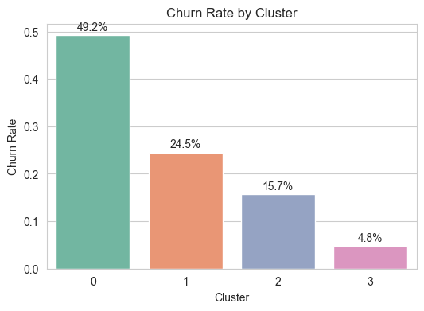

```python
# Visualise churn rate by cluster directly, since this is the single most business-relevant metric
fig, ax = plt.subplots(figsize=(6, 4))
sns.barplot(data=cluster_profile.reset_index(), x="cluster", y="churn_rate", hue="cluster", palette=palette, legend=False, ax=ax)
ax.set_title("Churn Rate by Cluster")
ax.set_ylabel("Churn Rate")
ax.set_xlabel("Cluster")
for i, v in enumerate(cluster_profile["churn_rate"]):
    ax.text(i, v + 0.01, f"{v:.1%}", ha="center")
plt.savefig("Cluster_Visualisation/churn_rate_by_cluster.png", dpi=300, bbox_inches="tight")
plt.show()
```

### Full Distribution Within Each Cluster

The table above only shows the *average* tenure and MonthlyCharges per cluster. To properly interpret the clusters, it's worth seeing the full spread of values within each one, since two clusters could have similar averages but very different internal spread.

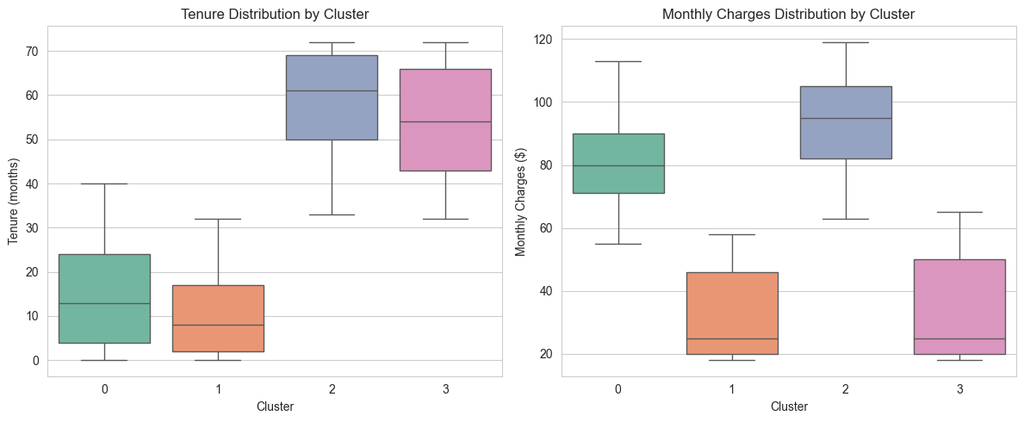

```python
# Visualise the full distribution of tenure and MonthlyCharges within each cluster,
# not just the summary means — shows spread and confirms no residual outliers
fig, axes = plt.subplots(1, 2, figsize=(12, 5))

sns.boxplot(data=profile_df, x="cluster", y="tenure", hue="cluster",
            palette=palette, legend=False, ax=axes[0])
axes[0].set_title("Tenure Distribution by Cluster")
axes[0].set_xlabel("Cluster")
axes[0].set_ylabel("Tenure (months)")

sns.boxplot(data=profile_df, x="cluster", y="MonthlyCharges", hue="cluster",
            palette=palette, legend=False, ax=axes[1])
axes[1].set_title("Monthly Charges Distribution by Cluster")
axes[1].set_xlabel("Cluster")
axes[1].set_ylabel("Monthly Charges ($)")

plt.tight_layout()
plt.savefig("Cluster_Visualisation/cluster_distributions.png", dpi=300, bbox_inches="tight")
plt.show()
```

> 🗂️ **Jira Task — Sprint 2 (Epic: Clustering Analysis):** Cross-validate cluster findings against an independent business rule

### Independent Cross-Check: Business-Rule Binning vs. Churn

As a sanity check on the clustering result, `tenure` is independently binned into simple business categories using `pd.cut()` — completely separate from the KMeans model — to confirm the same churn trend holds without relying on the clustering algorithm at all.

```python
# Independent sanity check: bin tenure into simple business categories,
# and compare the churn rate trend against the KMeans cluster results
profile_df['tenure_bin'] = pd.cut(
    profile_df['tenure'], bins=[-1, 12, 36, 72],
    labels=['New (0-12mo)', 'Established (12-36mo)', 'Loyal (36-72mo)']
)
profile_df.groupby('tenure_bin')['Churn'].mean().round(3)
```

```
tenure_bin
New (0-12mo)             0.474
Established (12-36mo)    0.255
Loyal (36-72mo)          0.119
Name: Churn, dtype: float64
```

**Finding:**

This simple, model-free binning shows the same monotonic pattern as the KMeans clusters — churn rate drops from ~47% for new customers, to ~26% for established customers, to ~12% for loyal customers. Since this trend holds under a completely independent method, it strengthens confidence that the clustering result reflects a genuine pattern in the data rather than an artifact of the K-Means algorithm.

```python
# Full categorical breakdown per cluster, for a more complete picture
categorical_breakdown = profile_df.groupby("cluster").agg(
    pct_male=("gender", "mean"),
    pct_senior=("SeniorCitizen", "mean"),
    pct_dependents=("Dependents", "mean"),
    pct_phone_service=("PhoneService", "mean"),
    pct_multiple_lines=("MultipleLines", "mean"),
    pct_fiber_optic=("InternetService", "mean"),
    pct_contract_m2m=("Contract_Month-to-month", "mean"),
    pct_contract_1yr=("Contract_One year", "mean"),
    pct_contract_2yr=("Contract_Two year", "mean"),
).round(3)

categorical_breakdown
```

| cluster | pct_male | pct_senior | pct_dependents | pct_phone_service | pct_multiple_lines | pct_fiber_optic | pct_contract_m2m | pct_contract_1yr | pct_contract_2yr |
| --- | --- | --- | --- | --- | --- | --- | --- | --- | --- |
| 0 | 0.495 | 0.231 | 0.196 | 0.993 | 0.423 | 0.430 | 0.561 | 0.192 | 0.247 |
| 1 | 0.523 | 0.072 | 0.304 | 0.797 | 0.418 | 0.441 | 0.540 | 0.227 | 0.233 |
| 2 | 0.502 | 0.216 | 0.332 | 0.988 | 0.433 | 0.449 | 0.553 | 0.207 | 0.240 |
| 3 | 0.502 | 0.077 | 0.436 | 0.749 | 0.407 | 0.441 | 0.541 | 0.219 | 0.241 |

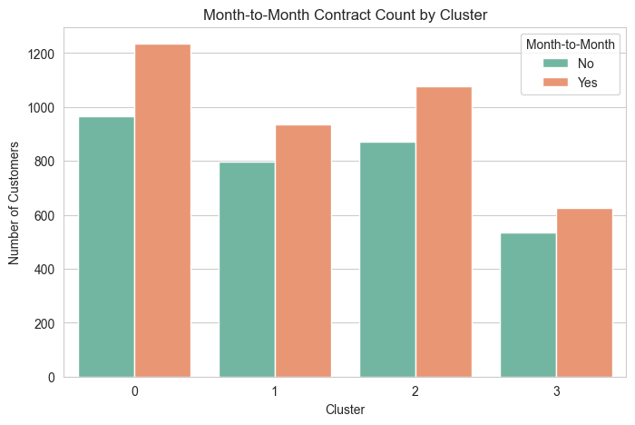

```python
# Visual complement to the categorical_breakdown table above:
# count of Month-to-month vs. other contracts within each cluster
fig, ax = plt.subplots(figsize=(8, 5))
sns.countplot(data=profile_df, x="cluster", hue="Contract_Month-to-month", palette="Set2", ax=ax)
ax.set_title("Month-to-Month Contract Count by Cluster")
ax.set_xlabel("Cluster")
ax.set_ylabel("Number of Customers")
ax.legend(title="Month-to-Month", labels=["No", "Yes"])
plt.show()
```

### Assigning Business-Meaningful Labels

Based on the profile above, each cluster is given a descriptive label to use throughout the rest of the report:

| Cluster | Label | Description |
| --- | --- | --- |
| 0 | **New, High-Spend — Highest Risk** | Low tenure (approx. 15 months), high charges (approx. \$81), by far the highest churn rate (49.2%) |
| 1 | **New, Low-Spend — Elevated Risk** | Low tenure (approx. 10 months), low charges (approx. \$32), moderately elevated churn (24.5%) |
| 2 | **Loyal, High-Spend — Low Risk** | Long tenure (approx. 59 months), high charges (approx. \$93), low churn (15.7%) |
| 3 | **Loyal, Low-Spend — Lowest Risk** | Long tenure (approx. 54 months), low charges (approx. \$34), lowest churn (4.8%) |

```python
# Map the descriptive labels onto the dataframe
cluster_labels = {
    0: "New, High-Spend - Highest Risk",
    1: "New, Low-Spend - Elevated Risk",
    2: "Loyal, High-Spend - Low Risk",
    3: "Loyal, Low-Spend - Lowest Risk",
}
profile_df["cluster_label"] = profile_df["cluster"].map(cluster_labels)
profile_df[["row_id", "cluster", "cluster_label"]].head()
```

|  | row_id | cluster | cluster_label |
| --- | --- | --- | --- |
| 0 | 0 | 1 | New, Low-Spend - Elevated Risk |
| 1 | 1 | 3 | Loyal, Low-Spend - Lowest Risk |
| 2 | 2 | 3 | Loyal, Low-Spend - Lowest Risk |
| 3 | 3 | 0 | New, High-Spend - Highest Risk |
| 4 | 4 | 3 | Loyal, Low-Spend - Lowest Risk |

## 8. Cross-Analysis: Clusters vs. Churn (Visual Summary)

A combined view of tenure, MonthlyCharges, cluster assignment, and Churn status — useful for the final report to visually tie the clustering results back to the project's core business question.

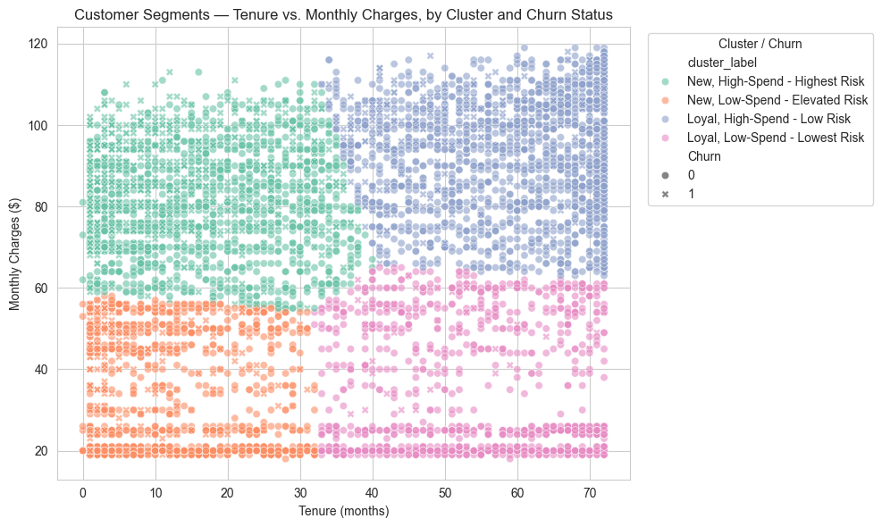

```python
fig, ax = plt.subplots(figsize=(10, 6))

# Colour each business label with the same colour its cluster number had in earlier plots
label_palette = {cluster_labels[i]: palette[i] for i in range(k_final)}

sns.scatterplot(
    data=profile_df, x="tenure", y="MonthlyCharges",
    hue="cluster_label", hue_order=list(cluster_labels.values()),
    style="Churn", palette=label_palette, alpha=0.6, ax=ax
)
ax.set_title("Customer Segments — Tenure vs. Monthly Charges, by Cluster and Churn Status")
ax.set_xlabel("Tenure (months)")
ax.set_ylabel("Monthly Charges ($)")
ax.legend(title="Cluster / Churn", bbox_to_anchor=(1.02, 1), loc="upper left")
plt.tight_layout()
plt.savefig("Cluster_Visualisation/segments_final.png", dpi=300, bbox_inches="tight")
plt.show()
```

> 🗂️ **Jira Task — Sprint 2 (Epic: Clustering Analysis):** Export cluster assignments & findings for downstream use

## 9. Export Cluster Assignments

Exporting `row_id` + cluster assignment + label, so the Business Analyst can join this onto any other view of the data, and so the Predictive Modeling DA can optionally test it as an additional ANN input feature — not required by the role brief, but available if useful. The file is saved in this notebook's own folder (`Clustering_Analysis/`).

```python
cluster_export = profile_df[["row_id", "cluster", "cluster_label"]].copy()
cluster_export.to_csv("cluster_assignments.csv", index=False)

print(f"Exported {len(cluster_export)} rows to cluster_assignments.csv")
cluster_export.head()
```

```
Exported 7043 rows to cluster_assignments.csv
```

|  | row_id | cluster | cluster_label |
| --- | --- | --- | --- |
| 0 | 0 | 1 | New, Low-Spend - Elevated Risk |
| 1 | 1 | 3 | Loyal, Low-Spend - Lowest Risk |
| 2 | 2 | 3 | Loyal, Low-Spend - Lowest Risk |
| 3 | 3 | 0 | New, High-Spend - Highest Risk |
| 4 | 4 | 3 | Loyal, Low-Spend - Lowest Risk |

## 10. Summary

**What this notebook did:**

- Loaded the data received from the Data Engineer (`clustering_features_scaled.csv`, `full_encoded_cleaned.csv`) and independently validated it (row counts, `row_id` integrity, missing values) before use
- Explored `tenure` and `MonthlyCharges` on their own terms, and found that churned customers concentrate in the low-tenure, higher-charge region — the basis for using these two features to cluster
- Used the Elbow Method and Silhouette Score to determine the optimal number of clusters (**k=4**)
- Trained a K-Means model on the scaled features and saved it to `Model/kmeans_model.joblib`
- Visualised the resulting clusters in both scaled and original feature space
- Joined cluster assignments back to the full feature set (confirming the encoding scheme against the raw source data first) to profile each cluster (tenure, charges, churn rate, contract type, service type, etc.)
- Assigned business-meaningful labels to each cluster, based on the actual profiling results:
  - **Cluster 0 — New, High-Spend, Highest Risk** (49.2% churn)
  - **Cluster 1 — New, Low-Spend, Elevated Risk** (24.5% churn)
  - **Cluster 2 — Loyal, High-Spend, Low Risk** (15.7% churn)
  - **Cluster 3 — Loyal, Low-Spend, Lowest Risk** (4.8% churn)
- Exported cluster assignments for use by the Business Analyst and, optionally, the Predictive Modeling DA

**Note on scope:** As flagged at the top of this notebook, some of the exploratory detail here (e.g. the full categorical breakdown in Section 7) is included for thoroughness rather than because it will all go into the final report — the Business Analyst should feel free to pull only the most relevant findings (likely the cluster profile table, the churn rate by cluster chart, and the final visualisation in Section 8).

**Next steps:**

- Business Analyst can pull `cluster_assignments.csv` plus the key visualisations and the four cluster labels above for the final report
- Predictive Modeling DA can optionally join `cluster_assignments.csv` (via `row_id`) onto the ANN training data to test whether cluster membership improves prediction performance